# Prosper loan data

## Preliminary Wrangling

This data has about 9 million cells which provides information about different loans and borrowers of the same bank

```python
# import all packages and set plots to be embedded inline
import numpy as np
import pandas as pd
import matplotlib.pyplot as plt
import seaborn as sb

%matplotlib inline

# suppress warnings from final output
import warnings
warnings.simplefilter("ignore")
```

```python
#loading the dataframe
loandata=pd.read_csv('ProsperLoanData.csv')
```

```python
#general overview of the dataframe
print(loandata.size)
print(loandata.shape)
```

```
9228897
(113937, 81)
```

```python
#quick look on the dataframe
loandata.head()
```

|  | ListingKey | ListingNumber | ListingCreationDate | CreditGrade | Term | LoanStatus | ClosedDate | BorrowerAPR | BorrowerRate | LenderYield | ... | LP_ServiceFees | LP_CollectionFees | LP_GrossPrincipalLoss | LP_NetPrincipalLoss | LP_NonPrincipalRecoverypayments | PercentFunded | Recommendations | InvestmentFromFriendsCount | InvestmentFromFriendsAmount | Investors |
| --- | --- | --- | --- | --- | --- | --- | --- | --- | --- | --- | --- | --- | --- | --- | --- | --- | --- | --- | --- | --- | --- |
| 0 | 1021339766868145413AB3B | 193129 | 2007-08-26 19:09:29.263000000 | C | 36 | Completed | 2009-08-14 00:00:00 | 0.16516 | 0.1580 | 0.1380 | ... | -133.18 | 0.0 | 0.0 | 0.0 | 0.0 | 1.0 | 0 | 0 | 0.0 | 258 |
| 1 | 10273602499503308B223C1 | 1209647 | 2014-02-27 08:28:07.900000000 | NaN | 36 | Current | NaN | 0.12016 | 0.0920 | 0.0820 | ... | 0.00 | 0.0 | 0.0 | 0.0 | 0.0 | 1.0 | 0 | 0 | 0.0 | 1 |
| 2 | 0EE9337825851032864889A | 81716 | 2007-01-05 15:00:47.090000000 | HR | 36 | Completed | 2009-12-17 00:00:00 | 0.28269 | 0.2750 | 0.2400 | ... | -24.20 | 0.0 | 0.0 | 0.0 | 0.0 | 1.0 | 0 | 0 | 0.0 | 41 |
| 3 | 0EF5356002482715299901A | 658116 | 2012-10-22 11:02:35.010000000 | NaN | 36 | Current | NaN | 0.12528 | 0.0974 | 0.0874 | ... | -108.01 | 0.0 | 0.0 | 0.0 | 0.0 | 1.0 | 0 | 0 | 0.0 | 158 |
| 4 | 0F023589499656230C5E3E2 | 909464 | 2013-09-14 18:38:39.097000000 | NaN | 36 | Current | NaN | 0.24614 | 0.2085 | 0.1985 | ... | -60.27 | 0.0 | 0.0 | 0.0 | 0.0 | 1.0 | 0 | 0 | 0.0 | 20 |

5 rows × 81 columns

```python
#overviewing dataframe's statistics
loandata.describe()
```

|  | ListingNumber | Term | BorrowerAPR | BorrowerRate | LenderYield | EstimatedEffectiveYield | EstimatedLoss | EstimatedReturn | ProsperRating (numeric) | ProsperScore | ... | LP_ServiceFees | LP_CollectionFees | LP_GrossPrincipalLoss | LP_NetPrincipalLoss | LP_NonPrincipalRecoverypayments | PercentFunded | Recommendations | InvestmentFromFriendsCount | InvestmentFromFriendsAmount | Investors |
| --- | --- | --- | --- | --- | --- | --- | --- | --- | --- | --- | --- | --- | --- | --- | --- | --- | --- | --- | --- | --- | --- |
| count | 1.139370e+05 | 113937.000000 | 113912.000000 | 113937.000000 | 113937.000000 | 84853.000000 | 84853.000000 | 84853.000000 | 84853.000000 | 84853.000000 | ... | 113937.000000 | 113937.000000 | 113937.000000 | 113937.000000 | 113937.000000 | 113937.000000 | 113937.000000 | 113937.000000 | 113937.000000 | 113937.000000 |
| mean | 6.278857e+05 | 40.830248 | 0.218828 | 0.192764 | 0.182701 | 0.168661 | 0.080306 | 0.096068 | 4.072243 | 5.950067 | ... | -54.725641 | -14.242698 | 700.446342 | 681.420499 | 25.142686 | 0.998584 | 0.048027 | 0.023460 | 16.550751 | 80.475228 |
| std | 3.280762e+05 | 10.436212 | 0.080364 | 0.074818 | 0.074516 | 0.068467 | 0.046764 | 0.030403 | 1.673227 | 2.376501 | ... | 60.675425 | 109.232758 | 2388.513831 | 2357.167068 | 275.657937 | 0.017919 | 0.332353 | 0.232412 | 294.545422 | 103.239020 |
| min | 4.000000e+00 | 12.000000 | 0.006530 | 0.000000 | -0.010000 | -0.182700 | 0.004900 | -0.182700 | 1.000000 | 1.000000 | ... | -664.870000 | -9274.750000 | -94.200000 | -954.550000 | 0.000000 | 0.700000 | 0.000000 | 0.000000 | 0.000000 | 1.000000 |
| 25% | 4.009190e+05 | 36.000000 | 0.156290 | 0.134000 | 0.124200 | 0.115670 | 0.042400 | 0.074080 | 3.000000 | 4.000000 | ... | -73.180000 | 0.000000 | 0.000000 | 0.000000 | 0.000000 | 1.000000 | 0.000000 | 0.000000 | 0.000000 | 2.000000 |
| 50% | 6.005540e+05 | 36.000000 | 0.209760 | 0.184000 | 0.173000 | 0.161500 | 0.072400 | 0.091700 | 4.000000 | 6.000000 | ... | -34.440000 | 0.000000 | 0.000000 | 0.000000 | 0.000000 | 1.000000 | 0.000000 | 0.000000 | 0.000000 | 44.000000 |
| 75% | 8.926340e+05 | 36.000000 | 0.283810 | 0.250000 | 0.240000 | 0.224300 | 0.112000 | 0.116600 | 5.000000 | 8.000000 | ... | -13.920000 | 0.000000 | 0.000000 | 0.000000 | 0.000000 | 1.000000 | 0.000000 | 0.000000 | 0.000000 | 115.000000 |
| max | 1.255725e+06 | 60.000000 | 0.512290 | 0.497500 | 0.492500 | 0.319900 | 0.366000 | 0.283700 | 7.000000 | 11.000000 | ... | 32.060000 | 0.000000 | 25000.000000 | 25000.000000 | 21117.900000 | 1.012500 | 39.000000 | 33.000000 | 25000.000000 | 1189.000000 |

8 rows × 61 columns

```python
#Dropping Duplicate rows :
#loandata.drop_duplicates()

#checking on duplicate Listing Numbers,Listing Keys and Loan Keys
lnumber=len(loandata['ListingNumber']) - len(loandata['ListingNumber'].value_counts())
lkey= len(loandata['ListingKey']) - len(loandata['ListingKey'].value_counts())
lokey=len(loandata['LoanKey']) - len(loandata['LoanKey'].value_counts())
print('Duplicate ListingNumber data: ',lnumber,'\nDuplicate ListingKey data: ',lkey,'\nDuplicate LoanKey data: ',lokey)
```

```
Duplicate ListingNumber data:  871
Duplicate ListingKey data:  871
Duplicate LoanKey data:  871
```

```python
#checking if the three columns have identical "duplicate columns"
#creating series of the duplicate columns

dupnum=np.array(loandata['ListingNumber'].value_counts())
dupkey=np.array(loandata['ListingKey'].value_counts())
duplokey=np.array(loandata['LoanKey'].value_counts())
if(dupnum==dupkey).all():
    print('same duplicates 1')
if(dupnum==duplokey).all():
    print('same duplcates 2')
```

```
same duplicates 1
same duplcates 2
```

```python
#Counting all null cells in sheet:

with pd.option_context('display.max_rows', None, 'display.max_columns', None):  # more options can be specified also
    print(loandata.isnull().sum())
```

```
ListingKey                                  0
ListingNumber                               0
ListingCreationDate                         0
CreditGrade                             84984
Term                                        0
LoanStatus                                  0
ClosedDate                              58848
BorrowerAPR                                25
BorrowerRate                                0
LenderYield                                 0
EstimatedEffectiveYield                 29084
EstimatedLoss                           29084
EstimatedReturn                         29084
ProsperRating (numeric)                 29084
ProsperRating (Alpha)                   29084
ProsperScore                            29084
ListingCategory (numeric)                   0
BorrowerState                            5515
Occupation                               3588
EmploymentStatus                         2255
EmploymentStatusDuration                 7625
IsBorrowerHomeowner                         0
CurrentlyInGroup                            0
GroupKey                               100596
DateCreditPulled                            0
CreditScoreRangeLower                     591
CreditScoreRangeUpper                     591
FirstRecordedCreditLine                   697
CurrentCreditLines                       7604
OpenCreditLines                          7604
TotalCreditLinespast7years                697
OpenRevolvingAccounts                       0
OpenRevolvingMonthlyPayment                 0
InquiriesLast6Months                      697
TotalInquiries                           1159
CurrentDelinquencies                      697
AmountDelinquent                         7622
DelinquenciesLast7Years                   990
PublicRecordsLast10Years                  697
PublicRecordsLast12Months                7604
```

[output cut: 27 more lines]

```
MonthlyLoanPayment                          0
LP_CustomerPayments                         0
LP_CustomerPrincipalPayments                0
LP_InterestandFees                          0
LP_ServiceFees                              0
LP_CollectionFees                           0
LP_GrossPrincipalLoss                       0
LP_NetPrincipalLoss                         0
LP_NonPrincipalRecoverypayments             0
PercentFunded                               0
Recommendations                             0
InvestmentFromFriendsCount                  0
InvestmentFromFriendsAmount                 0
Investors                                   0
dtype: int64
```

```python
#Convert Income Range column into ordered categorical data
Incomeranges={'IncomeRange':['$0','Not employed','$1-24,999','$25,000-49,999','$50,000-74,999','$100,000+']}
```

### What is the structure of your dataset?

There are 9228897 cells in the dataset with 113937 rows and 81 columns, most columns contain numeric variables.

### What is/are the main feature(s) of interest in your dataset?

I'm most interested in seeing how the occupation,original loan amount, stated monthly income features correlate with each other to better predict the loan status of a loan.

### What features in the dataset do you think will help support your investigation into your feature(s) of interest?

I expect some features such as borrower APR, Home ownership, no of credit lines,revolving credit balance and total trades to have an effect on the correlation.

## Univariate Exploration

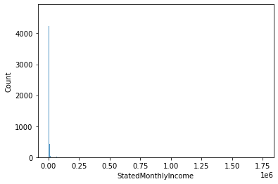

```python
#Distribution of monthly income
sb.histplot(data=loandata,x='StatedMonthlyIncome')
```

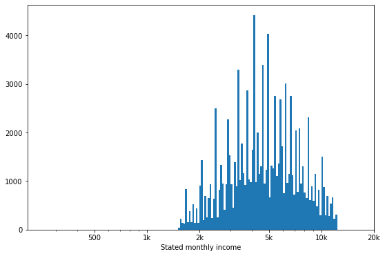

```python
#there's a long tail in the distribution and and outlier
#changing to log scale and removing oultiers
x=loandata['StatedMonthlyIncome']
x=x[x.between(x.quantile(0.05),x.quantile(0.95))]
log_binsize=0.01
bins = 10 ** np.arange(2.4, np.log10(x.max())+log_binsize, log_binsize)
plt.figure(figsize=[9,6])
plt.hist(x=x,bins=bins)
plt.xscale('log')
plt.xticks([500, 1e3, 2e3, 5e3, 1e4, 2e4], [500, '1k', '2k', '5k', '10k', '20k'])
plt.xlabel('Stated monthly income')
plt.show()
```

The plot is on a log scale and it is symmetric unimodal a peak at about 4k usd with outliers at 1million usd and many frequency spikes wich would endicate the commonality of some salaries more than others.

Instead of using the income range series I'll be using the stated monthly income series.

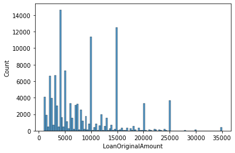

```python
#Distribution of loan amounts
sb.histplot(data=loandata,x='LoanOriginalAmount')
```

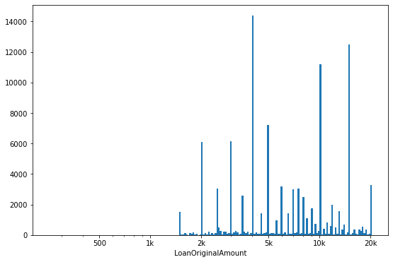

```python
#The plot is long tailed and has outliers changing to log scale and removing outliers
x=loandata['LoanOriginalAmount']
x=x[x.between(x.quantile(0.05),x.quantile(0.95))]
log_binsize=0.01
bins = 10 ** np.arange(2.4, np.log10(x.max())+log_binsize, log_binsize)
plt.figure(figsize=[9,6])
plt.hist(x=x,bins=bins)
plt.xscale('log')
plt.xticks([500, 1e3, 2e3, 5e3, 1e4, 2e4], [500, '1k', '2k', '5k', '10k', '20k'])
plt.xlabel('LoanOriginalAmount')
plt.show()
```

The is non uniformal with a peak at 4k usd and many frequency spikes at multiples of 5k usd

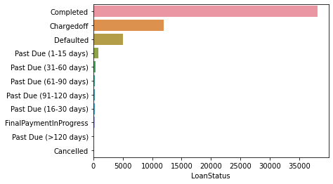

```python
#distribution of loan status
#and removing "current" loan status as it is
#not informative
x=loandata['LoanStatus'][loandata['LoanStatus']!='Current']
x=x.value_counts()

sb.barplot(x=x,y=x.index)
```

The plot shows how loans that are not delivered compose a big percentage of the total loans

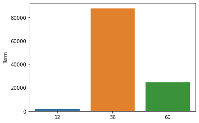

```python
#Terms distribution
x=loandata['Term'].value_counts()
sb.barplot(x=x.index,y=x)
```

36 months terms are the most focused on when taking a loan

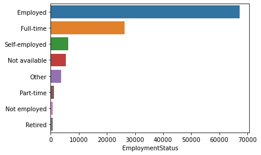

```python
x=loandata['EmploymentStatus'].value_counts()

sb.barplot(x=x,y=x.index)
```

Most borrowers sign their employment status as "employed" this is inefficient for the analysis as employed status would also include the part-time,full-time,self employed statuses.

### Discuss the distribution(s) of your variable(s) of interest. Were there any unusual points? Did you need to perform any transformations?

For Loan amounts and monthly payments there were outliers and I removed them

For Stated monthly income, I expected the distribution to be symmetrical unimodal aswell but it turned out to be nonuniform with many frequency spikes, might indicate that people state incomes that are different from their real income in order to earn some privilage, or just might mean that people calculate by approximation when stating their income.

### Of the features you investigated, were there any unusual distributions? Did you perform any operations on the data to tidy, adjust, or change the form of the data? If so, why did you do this?

Both original loan amounts plot and stated monthly income plot had long tailed distribution so i changed the scale and bins to log scale and log values bins

## Bivariate Exploration

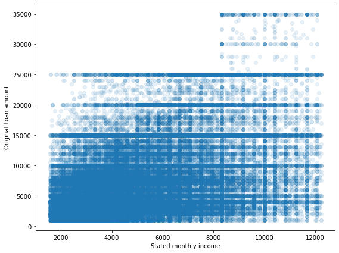

```python
#Loan amount and Monthly income
plt.figure(figsize=[9,7])
x=loandata
#removing outliers of stated monthly income
#for the whole dataset
x=x[x['StatedMonthlyIncome'].between(x['StatedMonthlyIncome'].quantile(0.05),x['StatedMonthlyIncome'].quantile(0.95))]

xx=x['StatedMonthlyIncome']
y=x['LoanOriginalAmount']

plt.scatter(x=xx,y=y,alpha=1/10)
plt.xlabel('Stated monthly income')
plt.ylabel('Original Loan amount')
plt.show()
```

Most borrowers under about 8.2 k usd monthly income don't make loans over 25k usd and from the scatter plot it seems that they tend to take lower loans the lower their salaries are but still the frequency spikes exist at multiples of 5k usd, borrowers with more than about 8.2k usd monthly income tend to take 35k usd loans more than other loans that are in the range of 26:35 k usd.

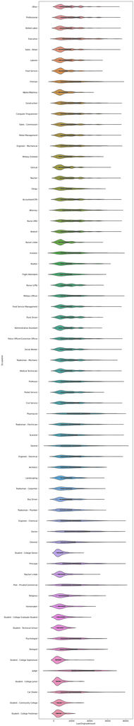

```python
#Occupation and Loan amount
plt.figure(figsize=[9,70])

sb.violinplot(data=loandata,x='LoanOriginalAmount',y='Occupation')
```

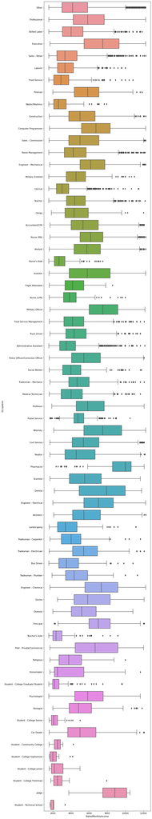

```python
#Occupation and Monthly income
plt.figure(figsize=[9,70])
x=loandata
x=x[x['StatedMonthlyIncome'].between(x['StatedMonthlyIncome'].quantile(0.05),x['StatedMonthlyIncome'].quantile(0.95))]

sb.boxplot(data=x,x='StatedMonthlyIncome',y='Occupation')
```

There is a surprising variety in income between each occupation and another is opposite to the commonality between loan amounts between each occupation, this interacts with the conclusions that stated the correlation between monthly income and loan amounts under 8.2k, where even though some occupations have a big difference in monthly income but their loan amounts are mostly common (under 8.2k) and only a small portion of occupations increase the Original loan amounts average.

#### occupation and loan status:

putting focus on the main incomplete and noncurrentloan statuses due to the difference between different occupations in counts, this relationship will be between the ratio of (defaulted/charged off) occupations to the total no of borrowers with that occupation individually in a collective comparison.

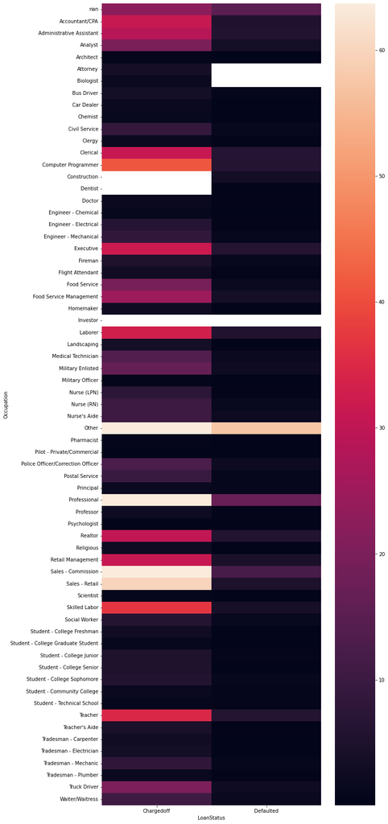

```python
x = loandata[(loandata['LoanStatus']=='Defaulted')|(loandata['LoanStatus']=='Chargedoff')]

defonly=loandata[(loandata['LoanStatus']=='Defaulted')]
defonlyratio=(defonly['Occupation'].value_counts().sort_index())/(loandata['Occupation'].value_counts().sort_index())


charonly=loandata[(loandata['LoanStatus']=='Chargedoff')]
charonlyratio=(charonly['Occupation'].value_counts().sort_index())/(loandata['Occupation'].value_counts().sort_index())



x =pd.DataFrame(data=[x['Occupation'],x['LoanStatus']]).transpose()
x=x.groupby(['Occupation','LoanStatus'],dropna=False).size().reset_index(name='Count')

x=x.pivot('Occupation','LoanStatus','Count')
x.sort_values(by='Occupation')

valuess=[]
for z in defonlyratio:
    valuess.append(z)
defratio=pd.Series(valuess)

valuesss=[]
for z in charonlyratio:
    valuesss.append(z)

chargedratio=pd.Series(valuesss)


x['chargedratio']=chargedratio.values
x['defaultedratio']=defratio.values

x['Chargedoff']=x['Chargedoff']*x['chargedratio']
x['Defaulted']=x['Defaulted']*x['defaultedratio']
x.drop(columns=['defaultedratio','chargedratio'],inplace=True)

plt.figure(figsize=[10,30])
sb.heatmap(data=x,robust=True)
```

The figure shows that there is a wide variety between borrowers jobs and not succeeding in delivering loans payments, highest Occupations would be (other,professional,sales-commission,sales-retail) it is advisable not to use "other" and "professional" occupations as they would themselves include different occupations aswell as the "nan" occupation.

1-Most borrowers who work in sales get chargedoff but their majority don't get defaulted.

2-Although the number of borrowers who get defaulted are less than ones who are chargedoff but they are both correlated in the same occupation.

4-Most occupations that get defaulted and charged off are of an unstable nature and would likely be jobs that depends on gigs or short contracts.

Checking other features correlations with chargedoff and defaulted loan statuses

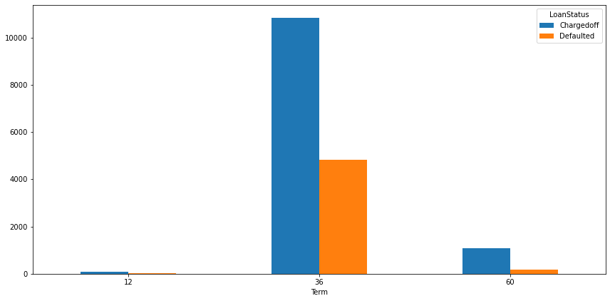

```python
#Term and loan status
x = loandata[(loandata['LoanStatus']=='Defaulted')|(loandata['LoanStatus']=='Chargedoff')]
x =pd.DataFrame(data=[x['Term'],x['LoanStatus']]).transpose()
x=x.groupby(['Term','LoanStatus'],dropna=False).size().reset_index(name='Count')
x=x.pivot('Term','LoanStatus','Count')
x.sort_values(by='Term')
fig, ax1 = plt.subplots(figsize=(12,6))
x['Term']=x.index
x.plot.bar(x='Term', ax=ax1)
plt.tight_layout()
plt.xticks(rotation=0)
plt.show()
```

From the plot it seems like 36 months term loans are the most loans with loan statuses as defaulted or charged off.

```python
#checking the total term loans to know if to expect loan status based on term or not.
((x['Defaulted']+x['Chargedoff'])/loandata['Term'].value_counts().sort_index())*100
```

```
Term
12     5.080545
36    17.835904
60     5.182318
dtype: float64
```

36 months term loans are expected to be defaulted or chargedoff more than three times as much as 12 and 60 months term loans each.

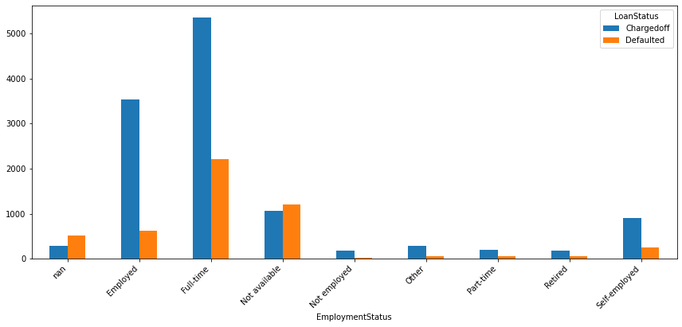

```python
#Employment status
x = loandata[(loandata['LoanStatus']=='Defaulted')|(loandata['LoanStatus']=='Chargedoff')]
x =pd.DataFrame(data=[x['EmploymentStatus'],x['LoanStatus']]).transpose()
x=x.groupby(['EmploymentStatus','LoanStatus'],dropna=False).size().reset_index(name='Count')
x=x.pivot('EmploymentStatus','LoanStatus','Count')
fig, ax1 = plt.subplots(figsize=(12,6))
x['EmploymentStatus']=x.index
x.plot.bar(x='EmploymentStatus', ax=ax1)
plt.tight_layout()
plt.xticks(rotation=45, ha="right")
plt.show()
```

Borrowers with employment statuses as "full-time" make the biggest portion of defaulted and chargedoff loan statuses. employment statuses as "nan" and "not available" are the only statuses that has a bigger defaulted loans than chargedoff loans.

```python
((x['Defaulted']+x['Chargedoff'])/loandata['EmploymentStatus'].value_counts().sort_index())*100
```

```
NaN                    NaN
Employed          6.177772
Full-time        28.685259
Not available    42.435010
Not employed     25.988024
Other             9.169732
Part-time        24.080882
Retired          29.937107
Self-employed    18.633844
dtype: float64
```

People with "not available" employment statuses have the highest expectations not to deliver their loans.

Although "employed" and "full-time" employment statuses made most of the defaulted and charged off loans, but their expectations to not deliver loans are (6 , 28) % which is close to other employment statuses.

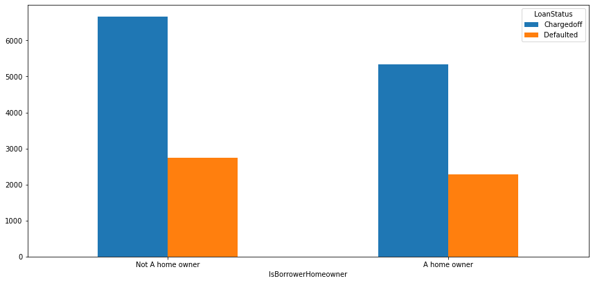

```python
#is borrower home owner
x = loandata[(loandata['LoanStatus']=='Defaulted')|(loandata['LoanStatus']=='Chargedoff')]
x =pd.DataFrame(data=[x['IsBorrowerHomeowner'],x['LoanStatus']]).transpose()
x=x.groupby(['IsBorrowerHomeowner','LoanStatus'],dropna=False).size().reset_index(name='Count')
x=x.pivot('IsBorrowerHomeowner','LoanStatus','Count')
fig, ax1 = plt.subplots(figsize=(12,6))
x['IsBorrowerHomeowner']=x.index
x.plot.bar(x='IsBorrowerHomeowner', ax=ax1)
plt.tight_layout()
plt.xticks(rotation=0,labels=['Not A home owner','A home owner'],ticks=[0,1])
plt.show()
```

The difference between each two bars is not big, although defaulted and chargedoff loans are more probable to have borrowers that don't own a home

```python
#Home ownership loan status ratio
((x['Defaulted']+x['Chargedoff'])/loandata['IsBorrowerHomeowner'].value_counts().sort_index())*100
```

```
IsBorrowerHomeowner
False    16.658106
True     13.231149
dtype: float64
```

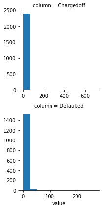

```python
#Borrower APR
x = loandata[(loandata['LoanStatus']=='Defaulted')|(loandata['LoanStatus']=='Chargedoff')]
x =pd.DataFrame(data=[x['BorrowerAPR'],x['LoanStatus']]).transpose()
x=x.groupby(['BorrowerAPR','LoanStatus'],dropna=False).size().reset_index(name='Count')
x=x.pivot('BorrowerAPR','LoanStatus','Count')
x=x.melt(var_name='column')
g = sb.FacetGrid(x, row='column',sharex=False, sharey=False)
g.map(plt.hist, 'value')
```

Displaying each with dynamic scale

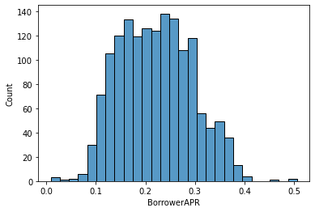

```python
#Defaulted and Borrower APR
x = loandata[(loandata['LoanStatus']=='Defaulted')]

x =pd.DataFrame(data=[x['BorrowerAPR'],x['LoanStatus']]).transpose()
x=x.groupby(['BorrowerAPR','LoanStatus'],dropna=False).size().reset_index(name='Count')
x=x.pivot('BorrowerAPR','LoanStatus','Count')
x['BorrowerAPR']=x.index
sb.histplot(data=x,x='BorrowerAPR')
```

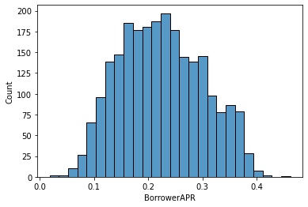

```python
#chargedoff and Borrower APR
x = loandata[(loandata['LoanStatus']=='Chargedoff')]

x =pd.DataFrame(data=[x['BorrowerAPR'],x['LoanStatus']]).transpose()
x=x.groupby(['BorrowerAPR','LoanStatus'],dropna=False).size().reset_index(name='Count')
x=x.pivot('BorrowerAPR','LoanStatus','Count')
x['BorrowerAPR']=x.index
sb.histplot(data=x,x='BorrowerAPR')
```

Both of the plots are roughly unimodal symmetrical both with a peak between 0.2 and 0.3 Borrower APR each.

### Talk about some of the relationships you observed in this part of the investigation. How did the feature(s) of interest vary with other features in the dataset?

I observed how some features of interest correlate with each other

1- there happened to be a wide variety betwen borrowers jobs and not succeeding in delivering loan paymets that is related to the nature of occupations.

3-There is a surprising variety in income between each occupation and another is opposite to the commonality between loan amounts between each occupation

### Did you observe any interesting relationships between the other features (not the main feature(s) of interest)?

1-36 months term loans are expected to be defaulted or chargedoff more than thrice as much as 12 and 60 months term loans.

## Multivariate Exploration

Investigating the relationship between the 4 main features (occupation,loan amount,loan status and stated monthly income)

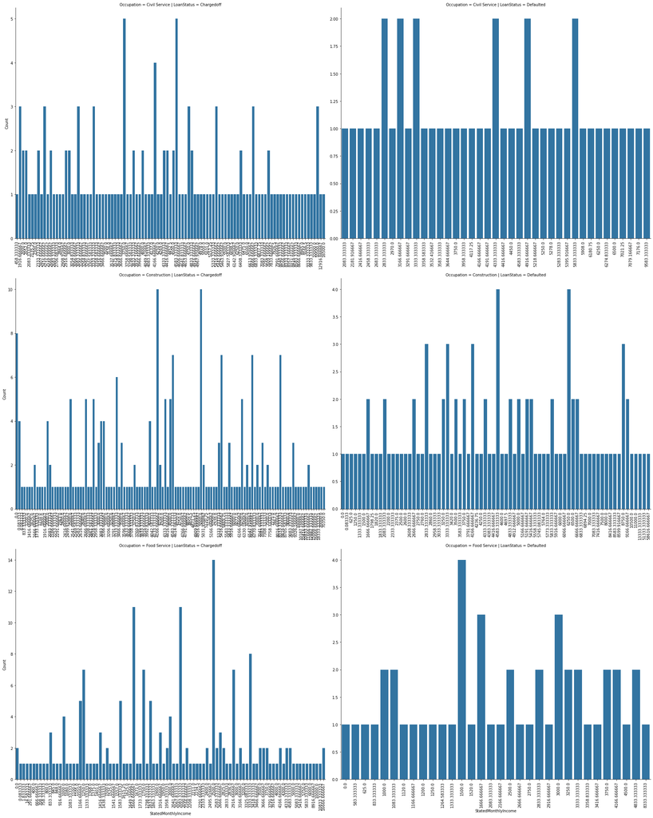

```python
#Occupation, LoanStatus and Stated Monthly Income
x = loandata[(loandata['LoanStatus']=='Defaulted')|(loandata['LoanStatus']=='Chargedoff')]
x=x.groupby(['Occupation','LoanStatus','StatedMonthlyIncome'],dropna=False).size().reset_index(name='Count')
x=x[(x['Occupation']=='Civil Service')|(x['Occupation']=='Food Service')|(x['Occupation']=='Construction')]
g = sb.FacetGrid(x, col='LoanStatus',row='Occupation',sharex=False, sharey=False, height=10, aspect=1.2)
for axes in g.axes.flat:
    _ = axes.set_xticklabels(axes.get_xticklabels(), rotation=90)
g.map(sb.barplot, 'StatedMonthlyIncome','Count')
```

The plots for stated monthly income indicate common nonuniform distributions between some occupations while each having unique maximum and minimum values, frequency spikes positions and concenterations.

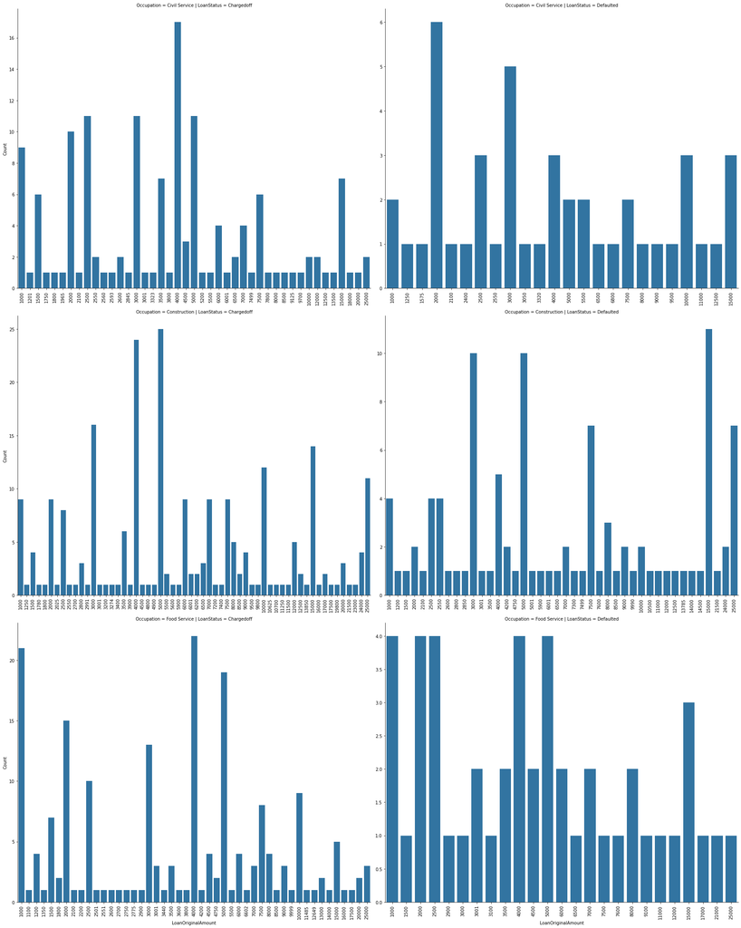

```python
#Occupation, LoanStatus and Loan Original Amount
x = loandata[(loandata['LoanStatus']=='Defaulted')|(loandata['LoanStatus']=='Chargedoff')]
x=x.groupby(['Occupation','LoanStatus','LoanOriginalAmount'],dropna=False).size().reset_index(name='Count')
x=x[(x['Occupation']=='Civil Service')|(x['Occupation']=='Food Service')|(x['Occupation']=='Construction')]
g = sb.FacetGrid(x, col='LoanStatus',row='Occupation',sharex=False, sharey=False, height=10, aspect=1.2)
for axes in g.axes.flat:
    _ = axes.set_xticklabels(axes.get_xticklabels(), rotation=90)
g.map(sb.barplot, 'LoanOriginalAmount','Count')
```

The plots for loan original amount indicates just as the plots of statedmonthly income indicated which are common nonuniform distributions between some occupations while each having unique maximum and minimum values, frequency spikes positions and concenterations.

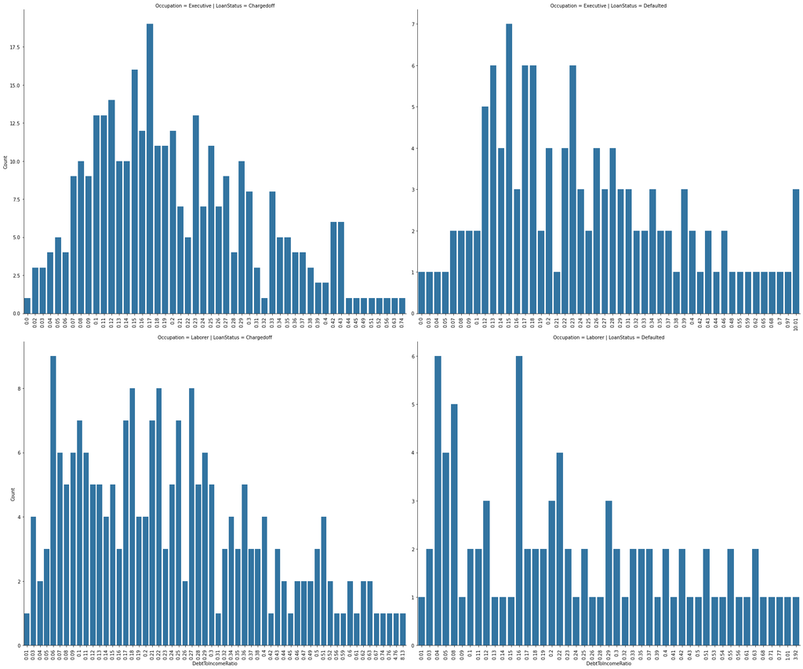

```python
x = loandata[(loandata['LoanStatus']=='Defaulted')|(loandata['LoanStatus']=='Chargedoff')]
x=x.groupby(['Occupation','LoanStatus','DebtToIncomeRatio'],dropna=False).size().reset_index(name='Count')
x=x[(x['Occupation']=='Executive')|(x['Occupation']=='Accountant')|(x['Occupation']=='Laborer')]
g = sb.FacetGrid(x, col='LoanStatus',row='Occupation',sharex=False, sharey=False, height=10, aspect=1.2)
for axes in g.axes.flat:
    _ = axes.set_xticklabels(axes.get_xticklabels(), rotation=90)
g.map(sb.barplot, 'DebtToIncomeRatio','Count')
```

Dept to income ratio has different distributions for each occupation aswell as different means and values.

The loan amount and stated monthly income facetgrid plots distribution are mostly nonuniform distributions with varying frequency peaks and means depending on occupation making every plot unique while having slight commonalities with other plots.

While the dept to income plots has a direct effect on the type of distribution a plot would have.

This indicates that the initial expectations that monthly income or loan amounts would have a correlation with loan status was wrong but instead the data shows that dept to income ratio has correlation with loan status that is different between each occupation and another There is a variety between plots maximum and minimum values for all facetgrids.

this variety between some occupations' distributions and commonality between others' while maintaining unique frequency spikes and peaks could be met with creating sets from this plot with each set containing occupations that have common distributions with taking notice the different peaks and medians as 2 or 3 values that distinguish each occupation inside it's set.

### Were there any interesting or surprising interactions between features?

While I expected all the dept to income grid plots to be right skewed distributions but some of the occupations who had sufficient data were not right skewed.